# Introdução aos gráficos

Daniel Maurenza de Oliveira

https://github.com/dmaurenza/Curso-Intermediario-R

Nesta aula vamos aprender a fazer gráficos (plot). Utilizaremos dois métodos diferentes. Primeiro, usando os comando do pacote R Base que já vem instalado no seu R. Segundo, usando o pacote ggplot2. Se quisermos fazer um gráfico exploratório rapidamente, a função plot do R base é suficiente. No entanto, as funções do pacote ggplot2 fornece muito mais ferramentas, dando maior versatilidade e elegância aos gráficos. Usaremos algumas tabelas de dados incluídos no R para facilitar a construção dos gráficos.

# Elementos da Aula

1. Gráficos de Dispersão
2. Gráficos de Linha
3. Graficos de Barra
4. Gráficos de Histogramas
5. Graficos Boxplot
6. Elementos visuais

## Gráficos de Dispersão

Para fazermos um gráfico de dispersão utilizamos duas informações básicas: o eixo x e o eixo y. A tabela “mtcars” já está embutida no R. Ela mostra a relação entre o consumo de combustível (mpg = Miles/(US) gallon) e outros 10 aspectos de automoveis para 32 modelos. Qual a relação entre o peso e o consumo de combustível?

- Utilizando o R base

```r
mtcars
```

```
##                      mpg cyl  disp  hp drat    wt  qsec vs am gear carb
## Mazda RX4           21.0   6 160.0 110 3.90 2.620 16.46  0  1    4    4
## Mazda RX4 Wag       21.0   6 160.0 110 3.90 2.875 17.02  0  1    4    4
## Datsun 710          22.8   4 108.0  93 3.85 2.320 18.61  1  1    4    1
## Hornet 4 Drive      21.4   6 258.0 110 3.08 3.215 19.44  1  0    3    1
## Hornet Sportabout   18.7   8 360.0 175 3.15 3.440 17.02  0  0    3    2
## Valiant             18.1   6 225.0 105 2.76 3.460 20.22  1  0    3    1
## Duster 360          14.3   8 360.0 245 3.21 3.570 15.84  0  0    3    4
## Merc 240D           24.4   4 146.7  62 3.69 3.190 20.00  1  0    4    2
## Merc 230            22.8   4 140.8  95 3.92 3.150 22.90  1  0    4    2
## Merc 280            19.2   6 167.6 123 3.92 3.440 18.30  1  0    4    4
## Merc 280C           17.8   6 167.6 123 3.92 3.440 18.90  1  0    4    4
## Merc 450SE          16.4   8 275.8 180 3.07 4.070 17.40  0  0    3    3
## Merc 450SL          17.3   8 275.8 180 3.07 3.730 17.60  0  0    3    3
## Merc 450SLC         15.2   8 275.8 180 3.07 3.780 18.00  0  0    3    3
## Cadillac Fleetwood  10.4   8 472.0 205 2.93 5.250 17.98  0  0    3    4
## Lincoln Continental 10.4   8 460.0 215 3.00 5.424 17.82  0  0    3    4
## Chrysler Imperial   14.7   8 440.0 230 3.23 5.345 17.42  0  0    3    4
## Fiat 128            32.4   4  78.7  66 4.08 2.200 19.47  1  1    4    1
## Honda Civic         30.4   4  75.7  52 4.93 1.615 18.52  1  1    4    2
## Toyota Corolla      33.9   4  71.1  65 4.22 1.835 19.90  1  1    4    1
## Toyota Corona       21.5   4 120.1  97 3.70 2.465 20.01  1  0    3    1
## Dodge Challenger    15.5   8 318.0 150 2.76 3.520 16.87  0  0    3    2
## AMC Javelin         15.2   8 304.0 150 3.15 3.435 17.30  0  0    3    2
## Camaro Z28          13.3   8 350.0 245 3.73 3.840 15.41  0  0    3    4
## Pontiac Firebird    19.2   8 400.0 175 3.08 3.845 17.05  0  0    3    2
## Fiat X1-9           27.3   4  79.0  66 4.08 1.935 18.90  1  1    4    1
## Porsche 914-2       26.0   4 120.3  91 4.43 2.140 16.70  0  1    5    2
## Lotus Europa        30.4   4  95.1 113 3.77 1.513 16.90  1  1    5    2
## Ford Pantera L      15.8   8 351.0 264 4.22 3.170 14.50  0  1    5    4
## Ferrari Dino        19.7   6 145.0 175 3.62 2.770 15.50  0  1    5    6
## Maserati Bora       15.0   8 301.0 335 3.54 3.570 14.60  0  1    5    8
## Volvo 142E          21.4   4 121.0 109 4.11 2.780 18.60  1  1    4    2
```

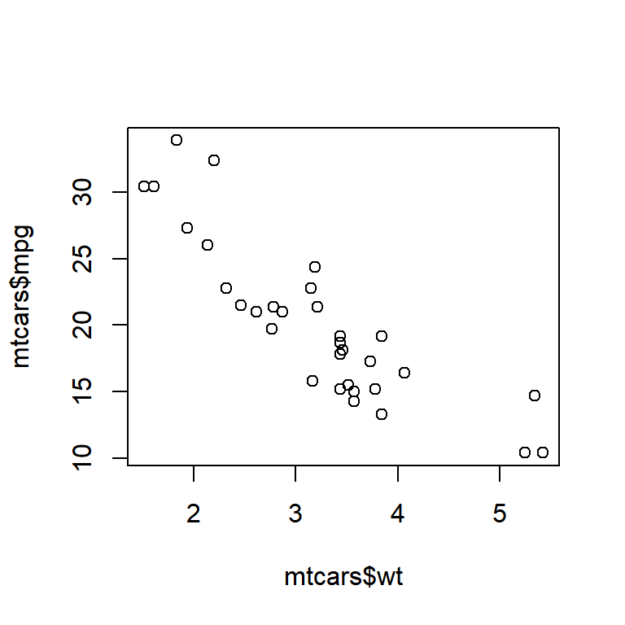

```r
plot(mtcars$wt, mtcars$mpg)
```

Resposta: quanto maior é o peso do carro (wt), menor é a eficiência de consumo (mpg).

Uma forma mais sucinta para a construção de gráficos é o uso da expressão “~” para indicarmos que os valores do eixo y variam “em função” dos valores do eixo x. No entanto, precisamos também indicar a tabela de origem dos dados

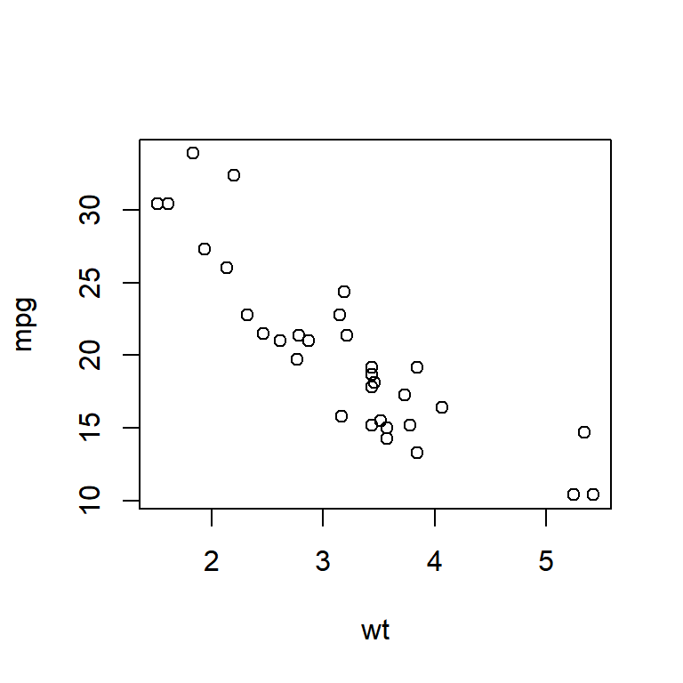

```r
plot(mpg ~ wt, data = mtcars)
```

- Utilizando o ggplot2

```r
library(ggplot2)
ggplot(data = mtcars, mapping = aes(x = wt, y = mpg)) +
  geom_point()
```

[output not shown]

A primeira parte (“ggplot”) cria o objeto plot. O argumento “data” nos diz ao objeto plot onde encontrar as variáveis que serão usadas. O argumento “mapping” possui a função aes() = aestetics, que mapeia ao objeto plot quais são as variáveis do eixo-x e eixo-y. A função “aes()” do argumento “mapping” NÃO diz onde estão as variáveis que podem ser usadas. A função aes() também defini elementos visuais, tais como cor, formato, tamanho e outras características, mas isso veremos na proxima aula.

A segunda parte (geom_point) adiciona a camada que informa o tipo de gráfico que será gerado através de uma função “geom_”, no caso, um gráfico de pontos. Note que sem adicionar a segunda parte, não temos um gráfico completo

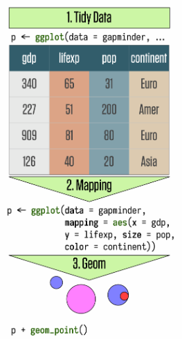

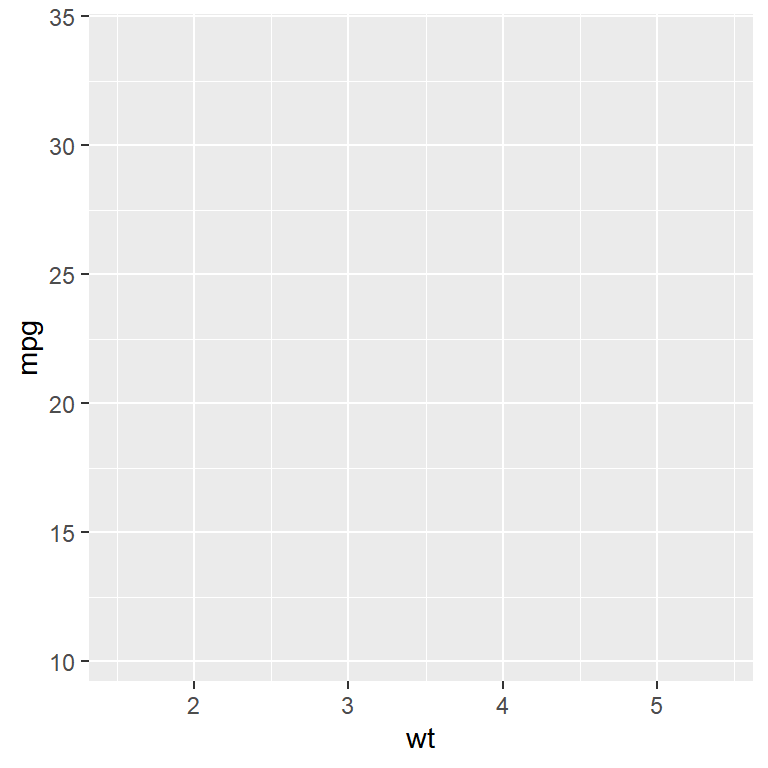

```r
ggplot(data = mtcars, mapping = aes(x = wt, y = mpg))
```

```r
ggplot(data = mtcars, mapping = aes(x = wt, y = mpg)) +
  geom_point()
```

[output not shown]

Percebam que o comando acima é igual a:

```r
p <- ggplot(data = mtcars, mapping = aes(x = wt, y = mpg))
p + geom_point()
```

Para iniciantes, é recomendado escrever os argumentos e separá-los em linhas para tornar mais agradável visualmente

```r
p = ggplot(data = mtcars,
       mapping = aes(x = wt,
                     y = mpg))
p +
  geom_point()
```

### Gráficos de Linha

- Para usarmos o R base, incluimos um vetor de valores x e um vetor de valores y na função plot()

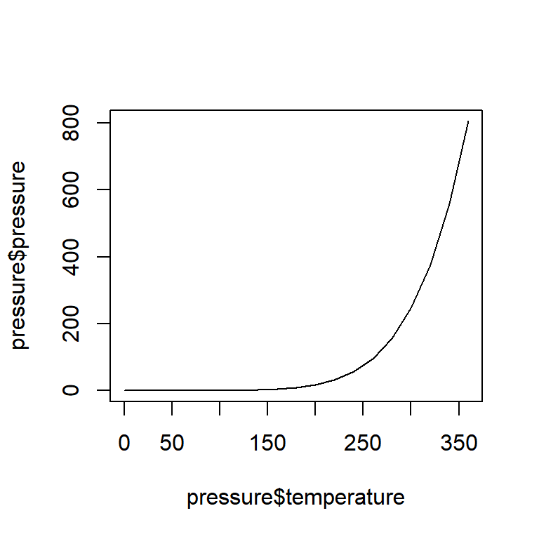

```r
plot(x = pressure$temperature, y = pressure$pressure, type = "l") # o argumento type = "l" indica que o gráfico será de linhas.
```

Para adicionarmos pontos e linhas, adicionamos as funções “points()” e “lines()”. Observe que ao usarmos a função plot e o argumento type = “l” criamos um gráfico de linhas. Porém, ao utilizarmos a função lines() acrescentamos linhas a um gráfico existente

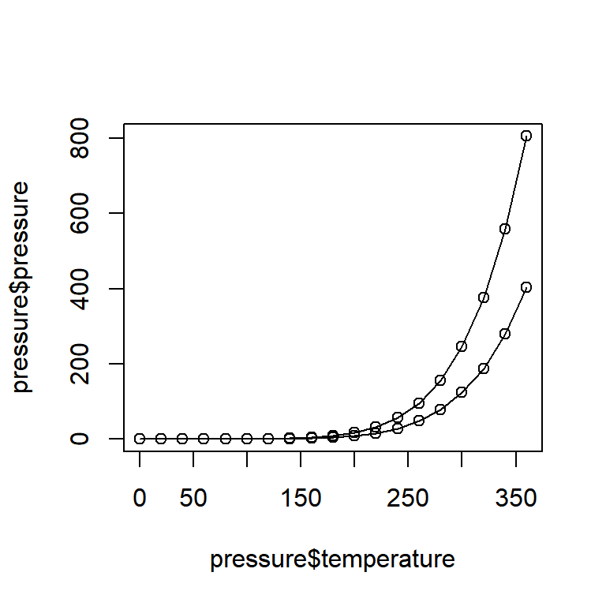

```r
plot(x = pressure$temperature, y = pressure$pressure, type = "l")

points(x = pressure$temperature, y = pressure$pressure)

lines(x = pressure$temperature, y = pressure$pressure/2)

points(x = pressure$temperature, y = pressure$pressure/2)
```

- Para usarmos o ggplot2, usamos a função geom_line

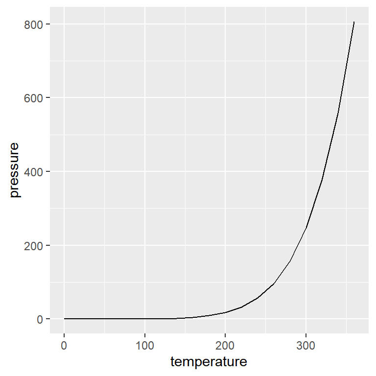

```r
p <- ggplot(pressure, aes(x = temperature, y = pressure))
p +
  geom_line()
```

Para adicionarmos pontos, adicionamos uma nova camada da função geom_points()

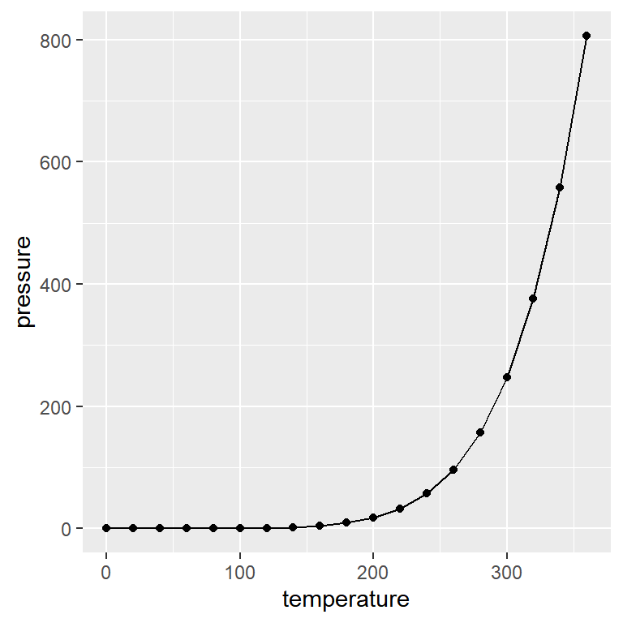

```r
p +
  geom_line() +
  geom_point()
```

### Gráficos de Barra

- Para usarmos o R base, usamos a função “barplot” incluindo um vetor de valores para a altura das barras, e um vetor de categorias para cada barra.

```r
BOD
```

```
##   Time demand
## 1    1    8.3
## 2    2   10.3
## 3    3   19.0
## 4    4   16.0
## 5    5   15.6
## 6    7   19.8
```

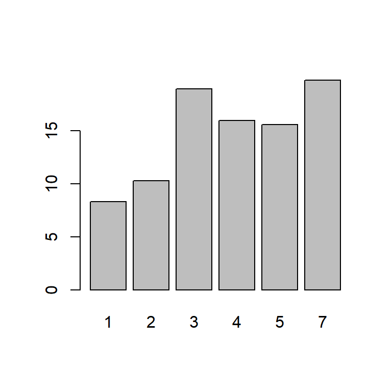

```r
barplot(BOD$demand, names.arg = BOD$Time)
```

Muitas vezes desejamos um gráfico de barras que mostre a frequência de observações em cada categoria. Para fazermos este gráfico, precisamos calcular a frenquência e fornecer estas informações para o gráfico (o número de observações em cada categoria)

```r
mtcars
```

```
##                      mpg cyl  disp  hp drat    wt  qsec vs am gear carb
## Mazda RX4           21.0   6 160.0 110 3.90 2.620 16.46  0  1    4    4
## Mazda RX4 Wag       21.0   6 160.0 110 3.90 2.875 17.02  0  1    4    4
## Datsun 710          22.8   4 108.0  93 3.85 2.320 18.61  1  1    4    1
## Hornet 4 Drive      21.4   6 258.0 110 3.08 3.215 19.44  1  0    3    1
## Hornet Sportabout   18.7   8 360.0 175 3.15 3.440 17.02  0  0    3    2
## Valiant             18.1   6 225.0 105 2.76 3.460 20.22  1  0    3    1
## Duster 360          14.3   8 360.0 245 3.21 3.570 15.84  0  0    3    4
## Merc 240D           24.4   4 146.7  62 3.69 3.190 20.00  1  0    4    2
## Merc 230            22.8   4 140.8  95 3.92 3.150 22.90  1  0    4    2
## Merc 280            19.2   6 167.6 123 3.92 3.440 18.30  1  0    4    4
## Merc 280C           17.8   6 167.6 123 3.92 3.440 18.90  1  0    4    4
## Merc 450SE          16.4   8 275.8 180 3.07 4.070 17.40  0  0    3    3
## Merc 450SL          17.3   8 275.8 180 3.07 3.730 17.60  0  0    3    3
## Merc 450SLC         15.2   8 275.8 180 3.07 3.780 18.00  0  0    3    3
## Cadillac Fleetwood  10.4   8 472.0 205 2.93 5.250 17.98  0  0    3    4
## Lincoln Continental 10.4   8 460.0 215 3.00 5.424 17.82  0  0    3    4
## Chrysler Imperial   14.7   8 440.0 230 3.23 5.345 17.42  0  0    3    4
## Fiat 128            32.4   4  78.7  66 4.08 2.200 19.47  1  1    4    1
## Honda Civic         30.4   4  75.7  52 4.93 1.615 18.52  1  1    4    2
## Toyota Corolla      33.9   4  71.1  65 4.22 1.835 19.90  1  1    4    1
## Toyota Corona       21.5   4 120.1  97 3.70 2.465 20.01  1  0    3    1
## Dodge Challenger    15.5   8 318.0 150 2.76 3.520 16.87  0  0    3    2
## AMC Javelin         15.2   8 304.0 150 3.15 3.435 17.30  0  0    3    2
## Camaro Z28          13.3   8 350.0 245 3.73 3.840 15.41  0  0    3    4
## Pontiac Firebird    19.2   8 400.0 175 3.08 3.845 17.05  0  0    3    2
## Fiat X1-9           27.3   4  79.0  66 4.08 1.935 18.90  1  1    4    1
## Porsche 914-2       26.0   4 120.3  91 4.43 2.140 16.70  0  1    5    2
## Lotus Europa        30.4   4  95.1 113 3.77 1.513 16.90  1  1    5    2
## Ford Pantera L      15.8   8 351.0 264 4.22 3.170 14.50  0  1    5    4
## Ferrari Dino        19.7   6 145.0 175 3.62 2.770 15.50  0  1    5    6
## Maserati Bora       15.0   8 301.0 335 3.54 3.570 14.60  0  1    5    8
## Volvo 142E          21.4   4 121.0 109 4.11 2.780 18.60  1  1    4    2
```

```r
mtcars$cyl
```

```
##  [1] 6 6 4 6 8 6 8 4 4 6 6 8 8 8 8 8 8 4 4 4 4 8 8 8 8 4 4 4 8 6 8 4
```

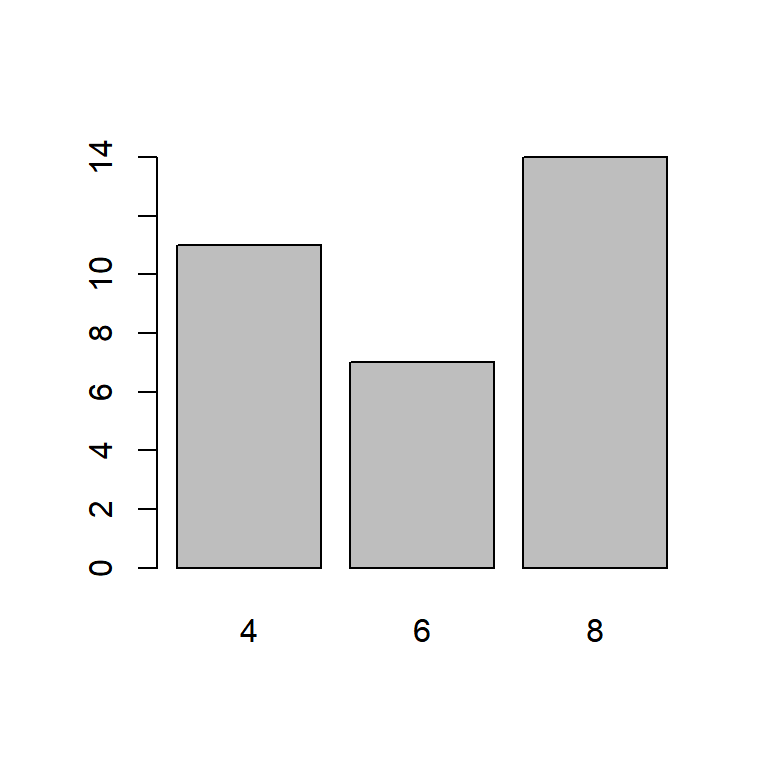

```r
tabela <- table(mtcars$cyl)

barplot(tabela)
```

- Utilizando o ggplot2. Para usarmos o ggplot2, também devemos oferecer um vetor de valores para a altura das barras, um vetor de categorias para cada barra e adicionamos a função “geom_col()”

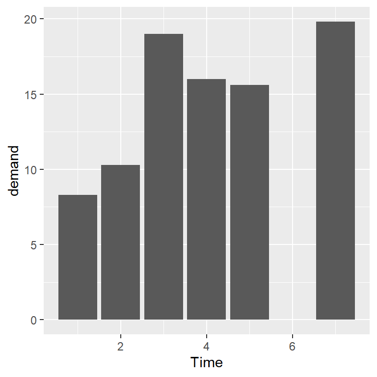

```r
p <- ggplot(data = BOD, mapping = aes(x = Time, y = demand))
p + geom_col()
```

Note que o ggplot2 diferencia variáveis contínuas das categóricas. Como utilizamos o vetor Time da classe numérica, o ggplot2 entende ser uma variável continua, que no caso, não tem valores para o Time = 6. Para interpretarmos Time como variável categórica, temos que usar a função factor() para este vetor.

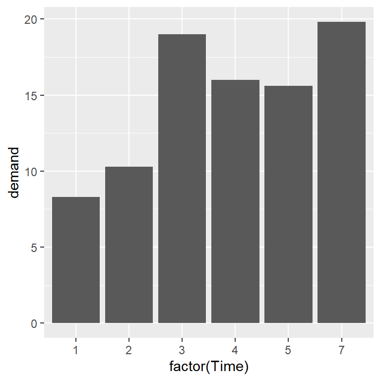

```r
p <- ggplot(data = BOD,
            mapping = aes(x = factor(Time),
                          y = demand))
p + geom_col()
```

Para mostrarmos a frequência das observações para cada categoria usando ggplot2 (similar a função table em R Base), usamos a função geom_bar, sem informar o eixo y, pois esse automaticamente representará a frequência das observação.

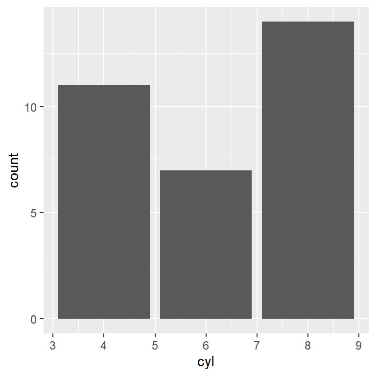

```r
p <- ggplot(mtcars, aes(x = cyl))
p + geom_bar()
```

Novamente, veja a diferença entre variável continua e categórica. Ao utilizarmos a função factor(), automaticamente o eixo y representa a frequência (número de linhas) de cada categoria da variável do eixo x.

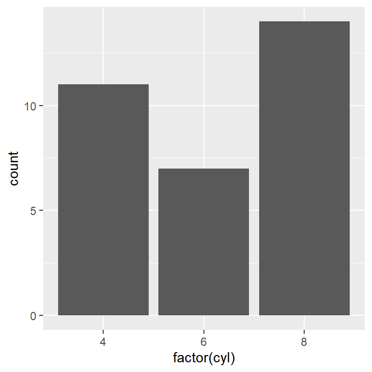

```r
p <- ggplot(mtcars, aes(x = factor(cyl)))
p + geom_bar()
```

### Gráficos de Histogramas

Diferente dos gráficos que vimos anteriormente, os histogramas são gráficos de 1 dimensão, que mostra a frequência de valores contínuos

- Usando o R base

```r
mtcars$mpg
```

```
##  [1] 21.0 21.0 22.8 21.4 18.7 18.1 14.3 24.4 22.8 19.2 17.8 16.4 17.3 15.2 10.4
## [16] 10.4 14.7 32.4 30.4 33.9 21.5 15.5 15.2 13.3 19.2 27.3 26.0 30.4 15.8 19.7
## [31] 15.0 21.4
```

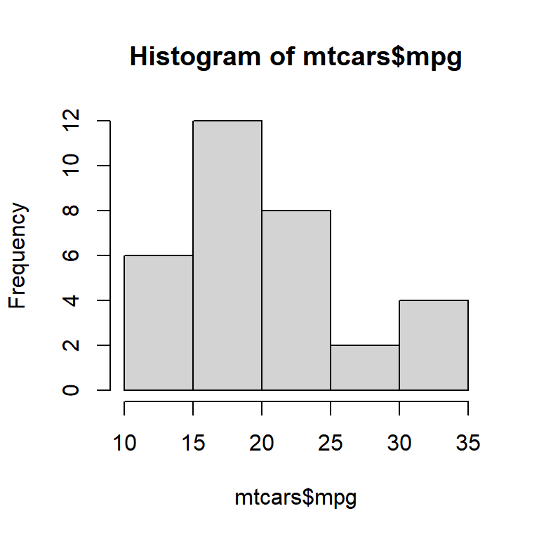

```r
hist(mtcars$mpg)
```

Podemos especificar o número de barras do histograma com o argumento “breaks”. Especificar o número de barra pode facilitar a visualização dos detalhes que queremos mostrar.

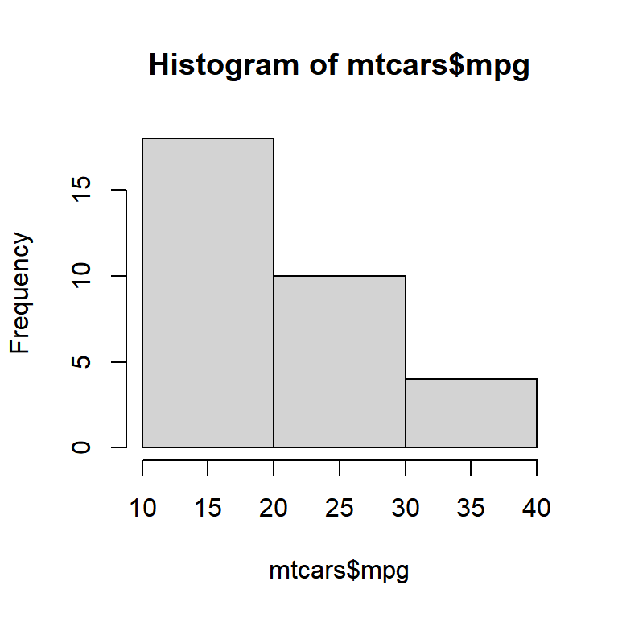

```r
hist(mtcars$mpg, breaks = 3)
```

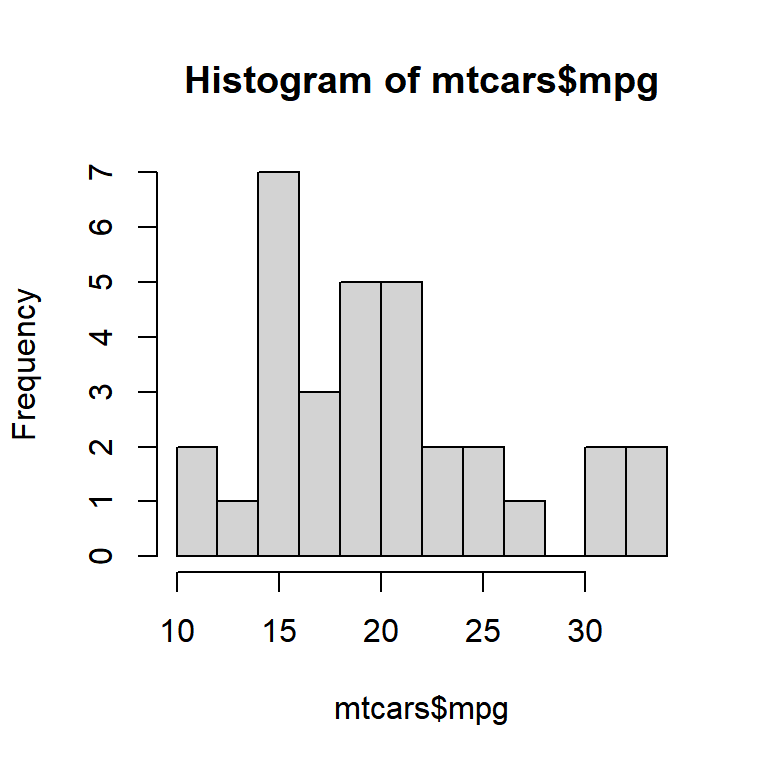

```r
hist(mtcars$mpg, breaks = 10)
```

- Usando o ggplot2

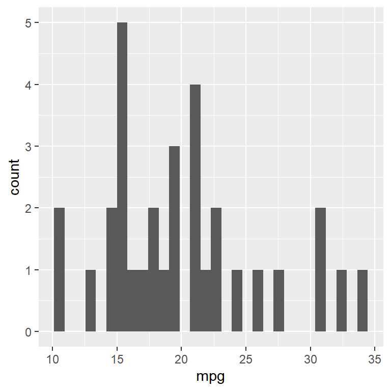

```r
p <- ggplot(mtcars, aes(x = mpg))
p +  geom_histogram()
```

Também podemos ajustar o número de barras usando o argumento “bins”

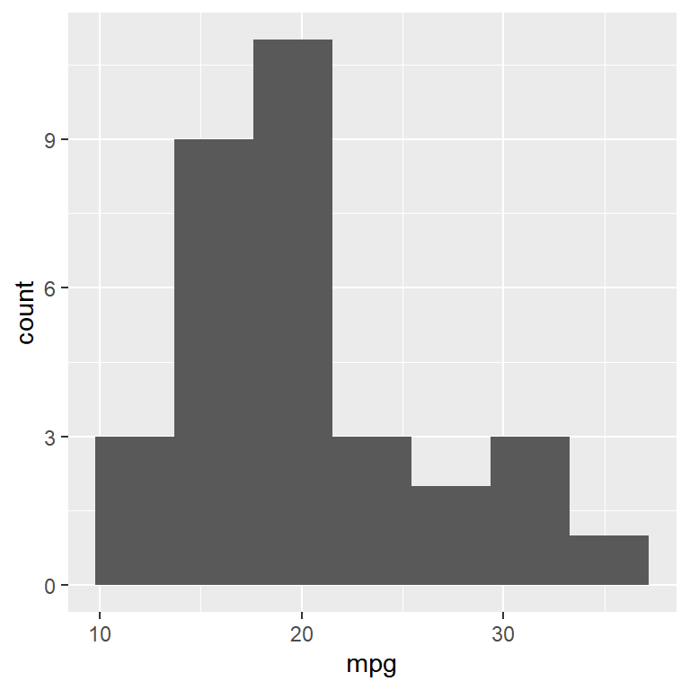

```r
p +  geom_histogram(bins = 7)
```

### Gráficos Boxplot

Boxplot é um tipo de gráfico frequentemente utilizado para visualizar a distribuição das observações. O Boxplot informa o valor máximo, mínimo, o primeiro (25%) e terceiro (75%) quartil, a mediana e se presente, os outliers.

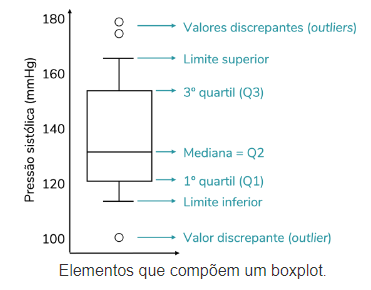

- Usando o R base

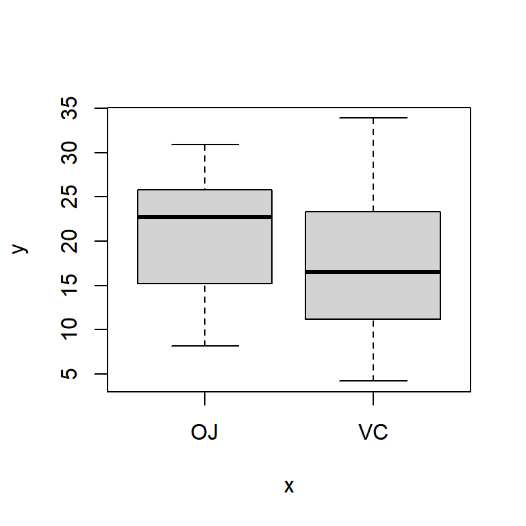

```r
plot(ToothGrowth$supp, ToothGrowth$len)
```

- Usando o ggplot2

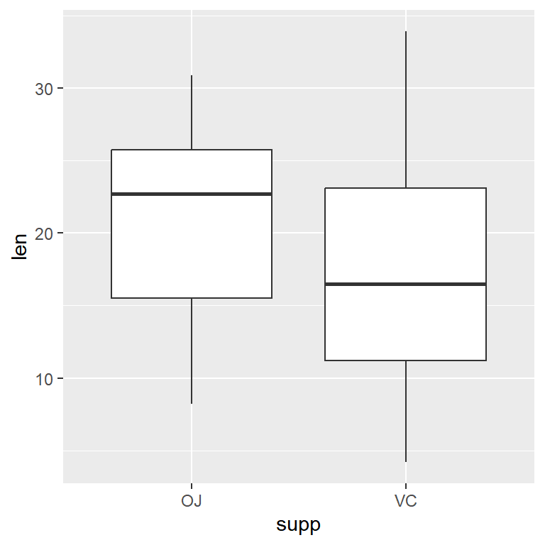

```r
p <- ggplot(ToothGrowth, aes(x = supp, y = len))
p +  geom_boxplot()
```

### Exercícios

1. Usando o pacote R base ou ggplot2 (mas tente usar os dois), faça um gráfico para cada tipo de gráfico (dispersão, linha, barra, histograma, e boxplot), usando qualquer variável da nossa planilha “Alunos”.
2. Qual pacote de gráfico você se sentiu mais confortável para usar? Porque?

### Elementos visuais

Conforme discutimos, o pacote ggplot2, embora mais complexo, apresenta maior versatilidade para a elaboração de gráficos, portanto, utilizaremos este pacote daqui em diante.

Vamos melhorar os gráficos, adicionando elementos visuais, tais como cores, tamanho, tipos, etc, de pontos, barras e linhas, que são os mais utilizados. Para inicialmente compreendermos o uso dos argumento visuais, vamos nos concentrar nos gráficos de dispersão

```r
#install.packages("gcookbook")
library(gcookbook) # Load gcookbook for the heightweight data set
library(dplyr)
head(heightweight)
```

```
##   sex ageYear ageMonth heightIn weightLb
## 1   f   11.92      143     56.3     85.0
## 2   f   12.92      155     62.3    105.0
## 3   f   12.75      153     63.3    108.0
## 4   f   13.42      161     59.0     92.0
## 5   f   15.92      191     62.5    112.5
## 6   f   14.25      171     62.5    112.0
```

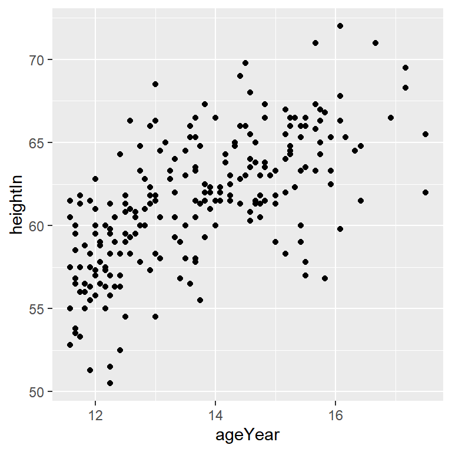

```r
p <- ggplot(heightweight, aes(x = ageYear, y = heightIn))
p + geom_point()
```

Ao invez de utilizarmos pontos para indicar a dispersão dos valores, podemos alterar o formato visual com o argumento “shape”

Veja as opções de formatos que existem

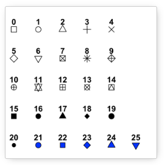

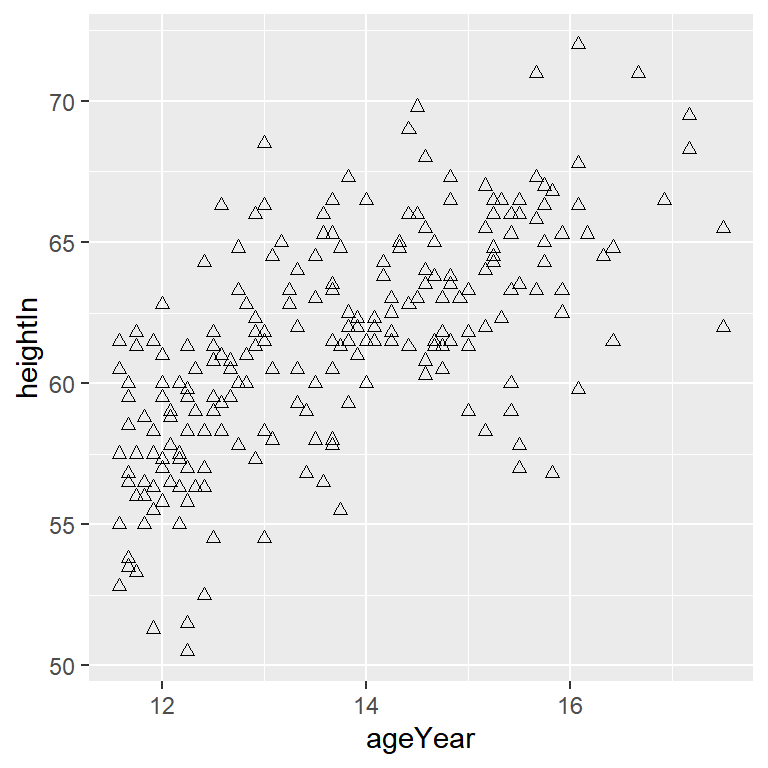

```r
p + geom_point(shape = 2)
```

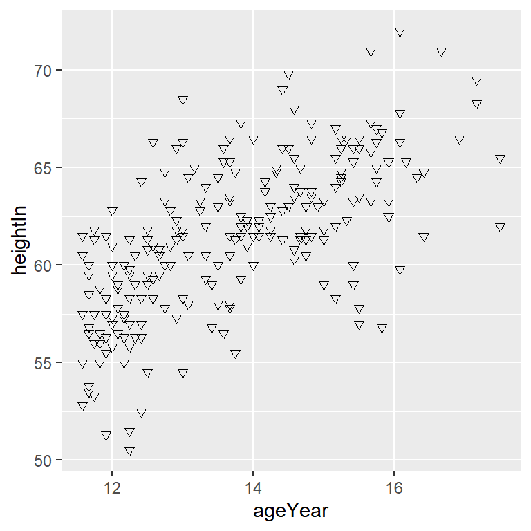

```r
p + geom_point(shape = 6)
```

Também podemos alterar o tamanho dos pontos, usando o argumento “size”

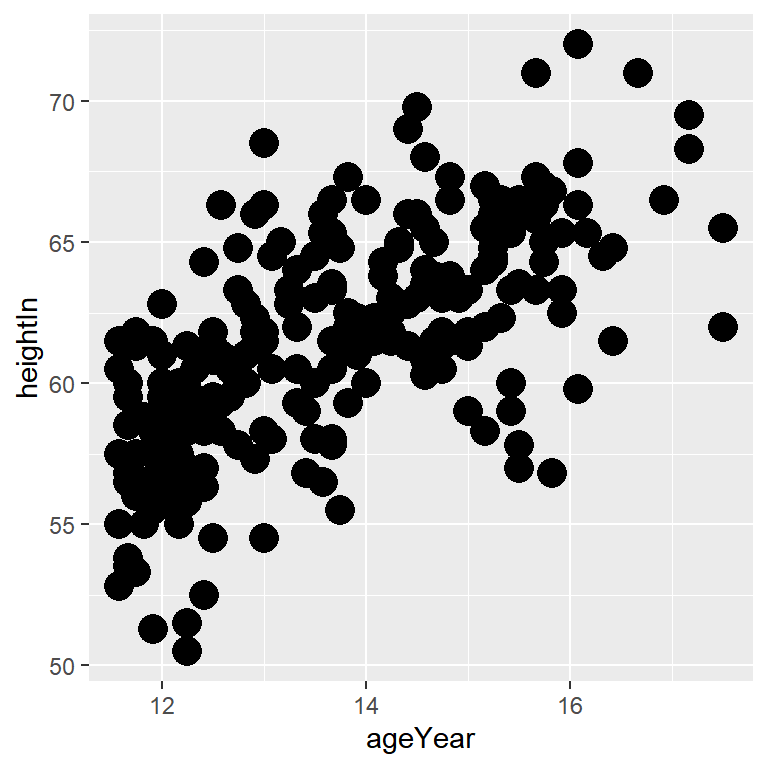

```r
p + geom_point(size = 5)
```

Similarmente, podemos alterar a cor com o argumento “color” ou “colour”, que pode ser um número, um caractere, ou um dos nomes indicados na figura abaixo.

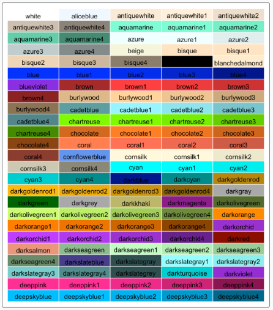

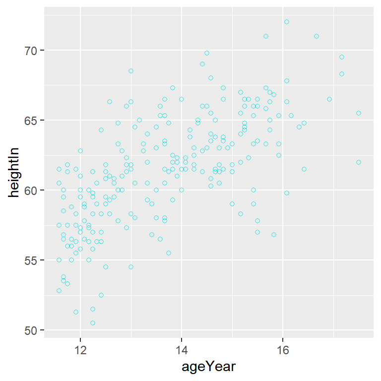

```r
p + geom_point(shape = 1, color = 5)
```